# Pitcher card

# John Schreiber

RHP · KC

2026 · 66 G (0 GS) · 997 pitches · Mar 29 – Sep 25, 2026

Independent portfolio sample by Devin Jenkinson, not affiliated with any club. Every number is computed from public Statcast data.

Three big takeaways

1Attack

The 4-seam fastball is the put-away pitch. Use it to finish at-bats.

43% of two-strike pitches · 23% whiffs/swing (78 swings)

It grades 94 Stuff+. Next best two-strike miss rate: the sweeper at 14%.

2Avoid

Limit the sweeper. It is his most damaging pitch.

When behind in the count he throws it 17% of the time; the cutter grades +0.83 there instead.

3Watch

Fastball height splits are too thin to call (82 swings up, 13 down).

Charts

### Movement

The ST finishes 27 in from his FF, with 25 in more glove-side run.

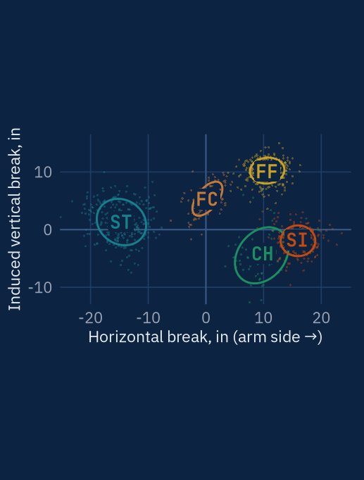

n = 997 pitches. Ellipses hold about 68% of each type; codes sit at the averages.

### Location by count

He throws 55% of pitches in the zone when behind and 37% when ahead.

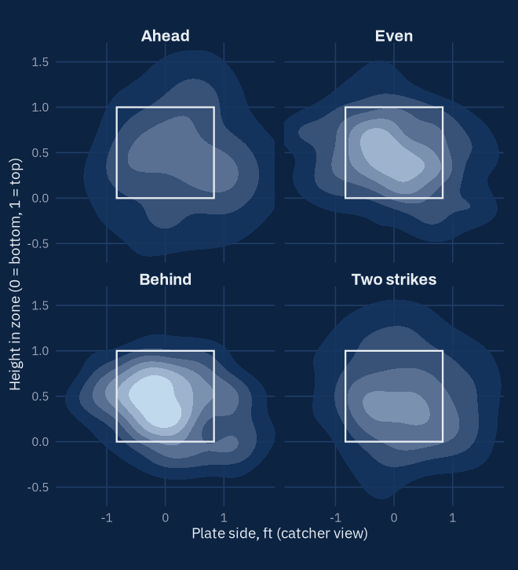

n = 997. Ahead 122 · even 352 · behind 229 · two strikes 294 pitches. Box = rule-book zone.

### Put-away

The FF is 43% of two-strike pitches vs 28% overall.

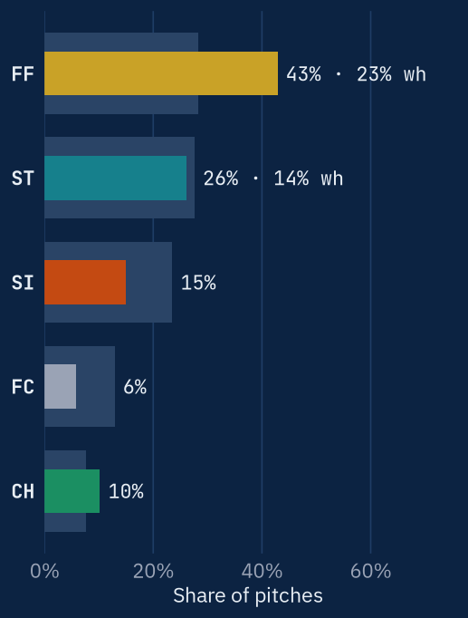

Two-strike n: FF 126, ST 77, SI 44, CH 30, FC 17. Grey bars = overall usage; wh = whiffs per swing (shown with 50+ swings).

### Arsenal

[output not shown]

IVB / HB in inches (HB + = arm side). VAA in degrees at the front of the plate. xRV/100 = expected run value per 100 pitches, pitcher’s view, shrunk with a 250-pitch prior. Stuff+ = this project’s shape-only model (100 = MLB average, 10 = 1 SD).

### Vs. batter hand

| Pitch | LHH # | Use | Whiff | xwOBAcon | RHH # | Use | Whiff | xwOBAcon |
| --- | --- | --- | --- | --- | --- | --- | --- | --- |
| FF | 126 | 28% | 16% | .404 | 153 | 28% | 31% | .068 |
| ST | 87 | 19% | – | .419 | 183 | 34% | 28% | .295 |
| SI | 89 | 19% | – | .338 | 168 | 31% | 12% | .348 |
| FC | 91 | 20% | 14% | .427 | 35 | 6% | – | .082 |
| CH | 65 | 14% | – | .232 | – | – | – | – |

Use = share of pitches to that side. Whiff = whiffs per swing, shown with 50+ swings.